# Analyzing Individual BGG Users

Phil Henrickson

2022-01-02

# **behryTov’s** BoardGameGeek Collection

This notebook contains a set of analyses for the selected user’s boardgamegeek collection. The bulk of the analysis is focused on building a user-specific predictive model to predict the games that behryTov is likely to own. This enables to ask questions like, based on the games the user currently owns, what games are a good fit for their collection? What upcoming games are they likely to purchase?

This analysis is based on data from BoardGameGeek that was last updated on **2021-12-20.**

# 1 Collection Overview

We can look at a basic description of the number of games that the user owns, has rated, has previously owned, etc.

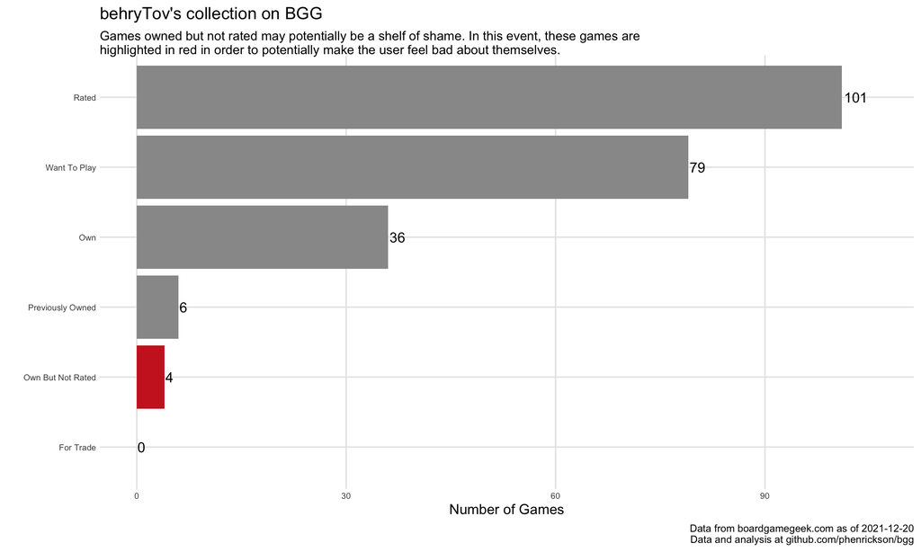

What years has the user owned/rated games from? While we can’t see when a user added or removed a game from their collection, we can look at their collection by the years in which their games were published.

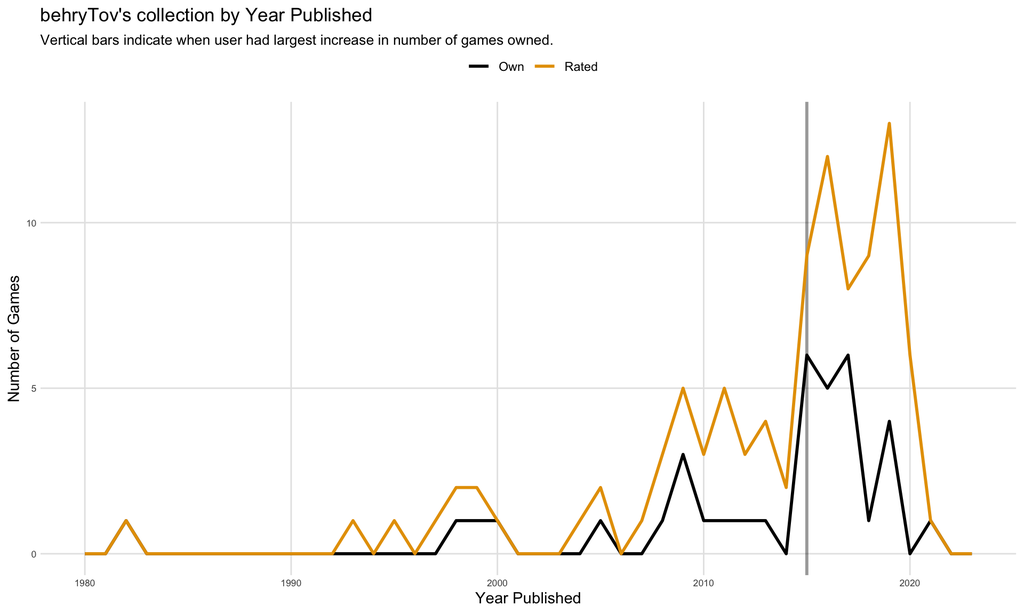

## 1.1 What types of games does behryTov own?

We can look at the most frequent types of categories, mechanics, designers, and artists that appear in a user’s collection.

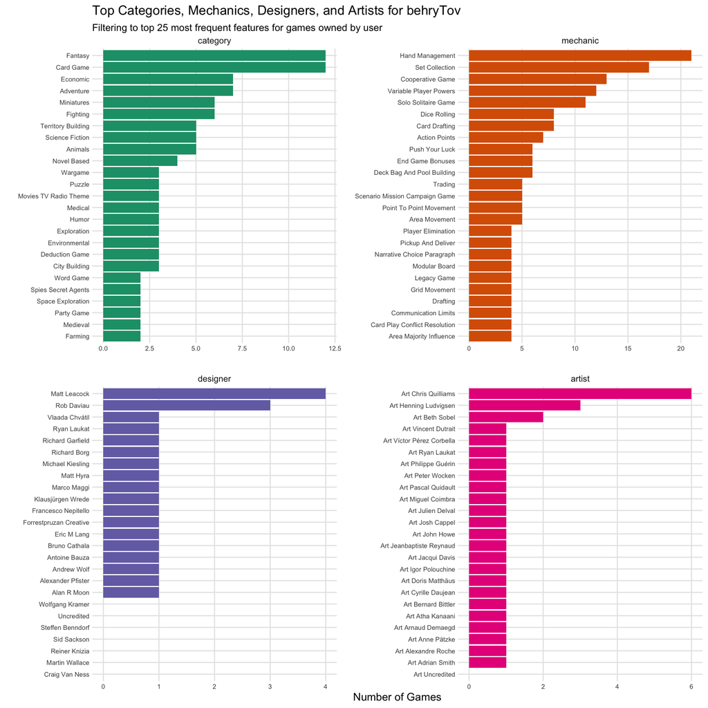

# 2 Modeling **behryTov’s** Collection

| username | dataset | period | games_owned | games_rated | games_played |
| --- | --- | --- | --- | --- | --- |
| behryTov | training | published before 2020 | 34 | 92 | 98 |
| behryTov | test | published 2020 or later | 1 | 7 | 7 |

There are two main (binary) outcomes we will be modeling for the user.

The first, **own** refers to whether the user currently lists a game as owned in their collection. The second, **played** refers to whether the user currently owns, has rated, or previously owned a game. This means the latter will generally have a larger list of games, but may still be a useful category to examine for people who play lots of games without necessarily owning them.

We will train predictive models to learn the probability that the user will own or play individual games based on their features.

## 2.1 Coefficients for behryTov

We can examine coefficients from the trained modes, which are penalized logistic regressions fit to our two main outcomes. Positive values indicate that a feature increases a user’s probabilility of owning/rating a game, while negative values indicate a feature decreases the probability.

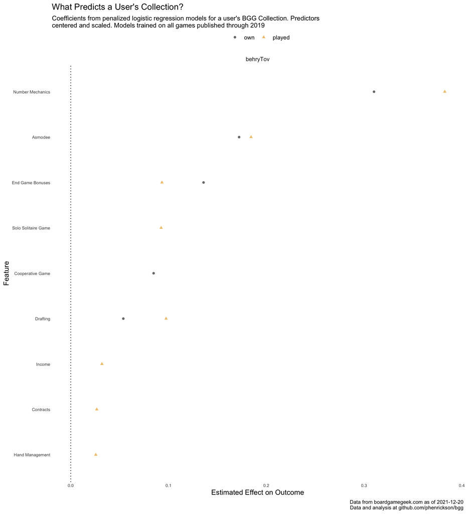

## 2.2 Visualizing Predictors for behryTov’s Collection

Why did the model identify these features? We can make density plots of the important features for predicting whether the user owned a game. Blue indicates the density for games owned by the user, while grey indicates the density for games not owned by the user.

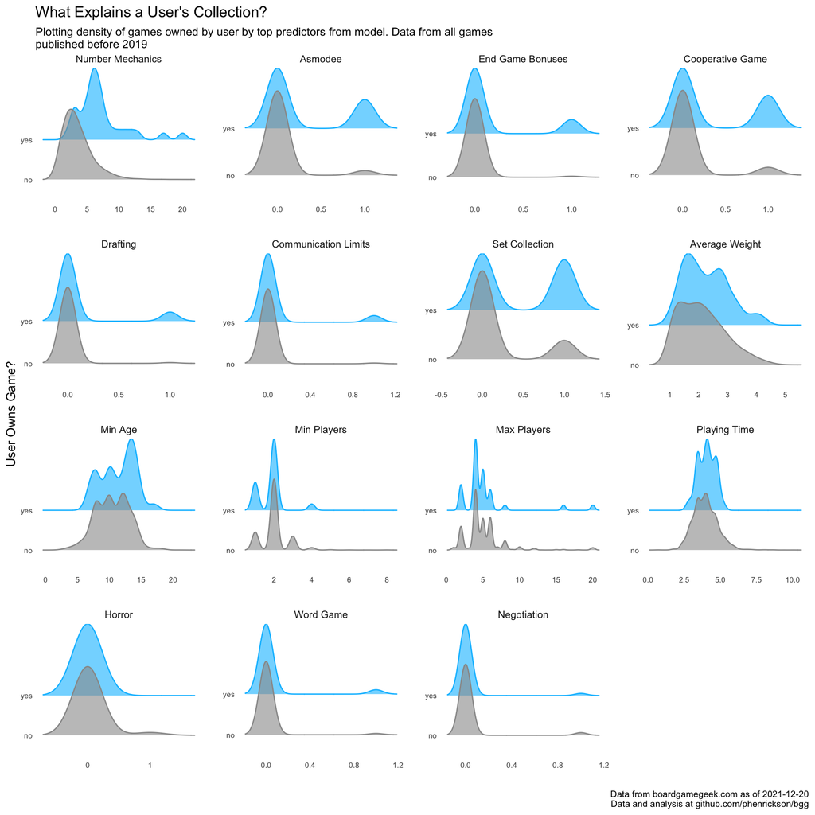

Binary predictors can be difficult to see with this visualization, so we can also directly examine the percentage of games in a user’s collection with a predictor vs the percentage of all games with that predictor.

| username | Feature | % of Games with Feature In_Collection | % of Games with Feature All_Games | Ratio |
| --- | --- | --- | --- | --- |
| behryTov | End Game Bonuses | 17.6% | 1.2% | 14.4 |
| behryTov | Drafting | 11.8% | 1.0% | 11.6 |
| behryTov | Communication Limits | 8.8% | 1.0% | 9.1 |
| behryTov | Asmodee | 32.4% | 5.3% | 6.1 |
| behryTov | Cooperative Game | 35.3% | 8.5% | 4.2 |
| behryTov | Word Game | 5.9% | 1.8% | 3.3 |
| behryTov | Set Collection | 47.1% | 17.5% | 2.7 |
| behryTov | Puzzle | 8.8% | 3.4% | 2.6 |
| behryTov | City Building | 8.8% | 4.3% | 2.1 |
| behryTov | Murdermystery | 2.9% | 1.8% | 1.7 |
| behryTov | Trivia | 2.9% | 1.8% | 1.6 |
| behryTov | Deduction Game | 8.8% | 6.4% | 1.4 |
| behryTov | Trains | 2.9% | 2.2% | 1.3 |
| behryTov | Medieval | 5.9% | 6.3% | 0.9 |
| behryTov | Negotiation | 2.9% | 3.7% | 0.8 |
| behryTov | Party Game | 5.9% | 8.5% | 0.7 |
| behryTov | Action Dexterity | 2.9% | 4.8% | 0.6 |
| behryTov | Horror | 0.0% | 4.0% | 0.0 |
| behryTov | Racing | 0.0% | 2.8% | 0.0 |
| behryTov | Mafia | 0.0% | 0.7% | 0.0 |
| behryTov | Prehistoric | 0.0% | 1.0% | 0.0 |
| behryTov | Realtime | 0.0% | 4.2% | 0.0 |
| behryTov | Sports | 0.0% | 2.0% | 0.0 |
| behryTov | Childrens Game | 0.0% | 5.7% | 0.0 |
| behryTov | Memory Game | 0.0% | 1.7% | 0.0 |

# 3 Assess Model’s Performance on Training Set

Before predicting games in upcoming years, we can examine how well the model did and what games it liked in the training set. In this case, we used resampling techniques (cross validation) to ensure that the model had not seen a game before making its predictions.

## 3.1 Separation Plot

An easy way to examine the performance of classification model is to view a separation plot. We plot the predicted probabilities from the model for every game (from resampling) from lowest to highest. We then overlay a blue line for any game that the user does own. A good classifier is one that is able to *separate* the blue (games owned by the user) from the white (games not owned by the user), with most of the blue occurring at the highest probabilities (right side of the chart).

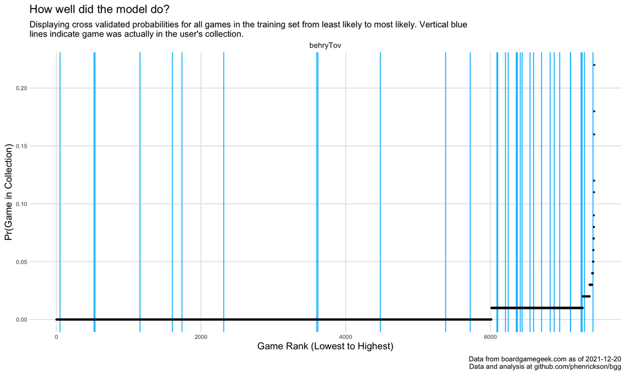

## 3.2 Top Games for **behryTov** from Training Set

We can display this information in table form, displaying the 100 games with the highest probability of ownership, adding a blue line when the user does own the game.

| username | yearpublished | game_id | name | pred_played | pred_own | actual_played | actual_own |
| --- | --- | --- | --- | --- | --- | --- | --- |
| behryTov | 2018 | 205896 | Rising Sun | 0.66 | 0.22 | 0 | 0 |
| behryTov | 2011 | 70919 | Takenoko | 0.21 | 0.18 | 0 | 0 |
| behryTov | 2019 | 283863 | The Magnificent | 0.49 | 0.16 | 0 | 0 |
| behryTov | 2018 | 244711 | Newton | 0.57 | 0.12 | 0 | 0 |
| behryTov | 2017 | 218603 | Photosynthesis | 0.10 | 0.11 | 0 | 0 |
| behryTov | 2017 | 188920 | This War of Mine: The Board Game | 0.08 | 0.09 | 0 | 0 |
| behryTov | 2010 | 62219 | Dominant Species | 0.09 | 0.08 | 0 | 0 |
| behryTov | 2012 | 122515 | Keyflower | 0.16 | 0.08 | 0 | 0 |
| behryTov | 2019 | 270971 | Era: Medieval Age | 0.30 | 0.07 | 0 | 0 |
| behryTov | 2018 | 256226 | Azul: Stained Glass of Sintra | 0.12 | 0.07 | 0 | 0 |
| behryTov | 2016 | 156858 | Black Orchestra | 0.06 | 0.07 | 0 | 0 |
| behryTov | 2005 | 18258 | Mission: Red Planet | 0.14 | 0.07 | 0 | 0 |
| behryTov | 2017 | 217861 | Paper Tales | 0.13 | 0.07 | 0 | 0 |
| behryTov | 2019 | 257066 | Sierra West | 0.13 | 0.06 | 0 | 0 |
| behryTov | 2016 | 185589 | Islebound | 0.16 | 0.06 | 0 | 0 |
| behryTov | 2015 | 175878 | 504 | 0.11 | 0.05 | 0 | 0 |
| behryTov | 2019 | 276025 | Maracaibo | 0.42 | 0.05 | 0 | 0 |
| behryTov | 2018 | 245928 | Pax Emancipation | 0.09 | 0.05 | 0 | 0 |
| behryTov | 2012 | 123096 | Space Cadets | 0.09 | 0.05 | 0 | 0 |
| behryTov | 2016 | 155821 | Inis | 0.10 | 0.04 | 0 | 0 |
| behryTov | 2015 | 169794 | Haspelknecht | 0.04 | 0.04 | 0 | 0 |
| behryTov | 2013 | 52461 | Legacy: The Testament of Duke de Crecy | 0.05 | 0.04 | 0 | 0 |
| behryTov | 2016 | 176083 | Hit Z Road | 0.18 | 0.04 | 0 | 0 |
| behryTov | 2017 | 220308 | Gaia Project | 0.17 | 0.04 | 0 | 0 |
| behryTov | 2019 | 251247 | Barrage | 0.15 | 0.04 | 0 | 0 |
| behryTov | 2018 | 246297 | Shadows: Amsterdam | 0.04 | 0.04 | 0 | 0 |
| behryTov | 1976 | 3083 | Submarine | 0.10 | 0.04 | 0 | 0 |
| behryTov | 2019 | 253635 | Ragusa | 0.17 | 0.04 | 0 | 0 |
| behryTov | 2019 | 271324 | It's a Wonderful World | 0.16 | 0.04 | 0 | 0 |
| behryTov | 2015 | 163967 | Tiny Epic Galaxies | 0.09 | 0.04 | 0 | 0 |

[output cut: 70 more lines]

We can also more formally assess how well the model did in resampling by looking at the area under the receiver operating characteristic. A perfect model would receive a score of 1, while a model that cannot predict the outcome will default to a score of 0.5. The extent to which something is a *good* score depends on the setting, but generally anything in the .8 to .9 range is very good while the .7 to .8 range is perfectly acceptable.

| username | outcome_type | .metric | .estimator | .estimate |
| --- | --- | --- | --- | --- |
| behryTov | own | roc_auc | binary | 0.791 |
| behryTov | played | roc_auc | binary | 0.838 |

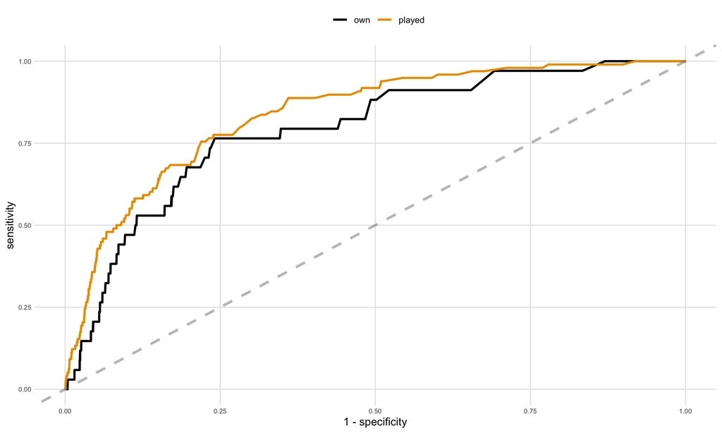

Another way to think about the model performance is to view its lift, or its ability to detect the positive outcomes over that of a null model. High lift indicates the model can much more quickly find all of the positive outcomes (in this case, games owned or played by the user), while a model with no lift is no better than random guessing.

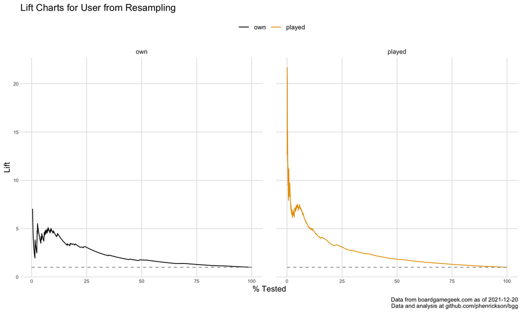

## 3.3 Most and Least Likely Games

What games does the model think behryTov is **most likely to own** that are **not** in their collection?

| username | yearpublished | game_id | name | pred_own | actual_own |
| --- | --- | --- | --- | --- | --- |
| behryTov | 2018 | 205896 | Rising Sun | 0.22 | 0 |
| behryTov | 2011 | 70919 | Takenoko | 0.18 | 0 |
| behryTov | 2019 | 283863 | The Magnificent | 0.16 | 0 |
| behryTov | 2018 | 244711 | Newton | 0.12 | 0 |
| behryTov | 2017 | 218603 | Photosynthesis | 0.11 | 0 |

What games does the model think behryTov is **least likely to own** that **are** in their collection?

| username | yearpublished | game_id | name | pred_own | actual_own |
| --- | --- | --- | --- | --- | --- |
| behryTov | 2013 | 146439 | BattleLore: Second Edition | 0 | 1 |
| behryTov | 2015 | 173346 | 7 Wonders Duel | 0 | 1 |
| behryTov | 2017 | 221965 | The Fox in the Forest | 0 | 1 |
| behryTov | 2015 | 172818 | Above and Below | 0 | 1 |
| behryTov | 2015 | 161936 | Pandemic Legacy: Season 1 | 0 | 1 |

## 3.4 Top Games by Year

Top 25 games most likely to be owned by the user in each year, highlighting in blue the games that the user has owned/played.

| rank | 2011 | 2012 | 2013 | 2014 | 2015 | 2016 | 2017 | 2018 | 2019 |
| --- | --- | --- | --- | --- | --- | --- | --- | --- | --- |
| 1 | Takenoko | Keyflower | Legacy: The Testament of Duke de Crecy | Patchwork | 504 | Black Orchestra | Photosynthesis | Rising Sun | The Magnificent |
| 2 | A Few Acres of Snow | Space Cadets | Zombicide Season 2: Prison Outbreak | Castles of Mad King Ludwig | Haspelknecht | Islebound | This War of Mine: The Board Game | Newton | Era: Medieval Age |
| 3 | Mage Knight Board Game | Suburbia | Bomb Squad | La Granja | Tiny Epic Galaxies | Inis | Paper Tales | Azul: Stained Glass of Sintra | Sierra West |
| 4 | Sekigahara: The Unification of Japan | Robinson Crusoe: Adventures on the Cursed Island | Sushi Go! | Camel Up | The Pursuit of Happiness | Hit Z Road | Gaia Project | Pax Emancipation | Maracaibo |
| 5 | Space Infantry | Serenissima (Second Edition) | Concept | Akrotiri | Mysterium | Terraforming Mars | Pulsar 2849 | Shadows: Amsterdam | Barrage |
| 6 | Ascension: Return of the Fallen | Seasons | Rory's Story Cubes: Prehistoria | Sons of Anarchy: Men of Mayhem | FUSE | Clank!: A Deck-Building Adventure | Azul | Heroes of Terrinoth | Ragusa |
| 7 | Drako: Dragon & Dwarves | Santa Cruz | Impulse | Arcadia Quest | Bastion | Agricola (Revised Edition) | A Tale of Pirates | Underwater Cities | It's a Wonderful World |
| 8 | Streams | Exodus: Proxima Centauri | Room 25 | Black Fleet | The King Is Dead | Sushi Go Party! | Harvest Dice | Blue Lagoon | The Isle of Cats |
| 9 | The Castles of Burgundy | Zombicide | Brew Crafters | Witness | Warhammer Age of Sigmar | Mansions of Madness: Second Edition | Too Many Bones | Holding On: The Troubled Life of Billy Kerr | Yukon Airways |
| 10 | The Gnomes of Zavandor | Libertalia | Forbidden Desert | Spyfall | The U.S. Civil War | Yokohama | Breaking Bad: The Board Game | The Grizzled: Armistice Edition | Old West Empresario |
| 11 | Village | Descent: Journeys in the Dark (Second Edition) | Crusade and Revolution: The Spanish Civil War, 1936-1939 | Deception: Murder in Hong Kong | ...and then, we held hands. | Imhotep | Muse | Gingerbread House | Tainted Grail: The Fall of Avalon |
| 12 | Feudalia | Escape: The Curse of the Temple | Dungeon Twister: The Card Game | Colt Express | Sylvion | Pandemic: Reign of Cthulhu | Sub Terra | Vengeance | Zombicide: Invader |
| 13 | Gears of War: The Board Game | Mage Wars Arena | Rivet Wars: Eastern Front | Saboteur: The Duel | Hoplomachus: Origins | Mistfall: Heart of the Mists | Unlock!: Escape Adventures – Temple of Ra | Sprawlopolis | Cloudspire |
| 14 | Space Empires: 4X | Kingdom of Heaven: The Crusader States 1097-1291 | Hoplomachus: Rise of Rome | Onirim (Second Edition) | Raptor | Beyond Baker Street | Exploding Kittens: Party Pack | Decrypto | Middara: Unintentional Malum – Act 1 |
| 15 | The Secret of Monte Cristo | Targi | The Hunters: German U-Boats at War, 1939-43 | Pathfinder Adventure Card Game: Skull & Shackles – Base Set | Coffee Roaster | Captain Sonar | The Godfather: Corleone's Empire | Muse: Awakenings | MegaCity: Oceania |
| 16 | Discworld: Ankh-Morpork | 1989: Dawn of Freedom | Pizza Party | Waggle Dance | Justice League: Hero Dice – Superman | Citadels | Dungeon Time | Western Legends | Minecraft: Builders & Biomes |
| 17 | Octopus's Garden | Polis: Fight for the Hegemony | Cruel Necessity: The English Civil Wars 1640-1653 | Deus | Brick Party | Codenames: Pictures | Century: Spice Road | Betrayal Legacy | Century: A New World |
| 18 | Kingdom Builder | In Magnificent Style: Pickett's Charge at Gettysburg | Rogue Agent | Shadows of Brimstone: Swamps of Death | Chaosmos | When I Dream | The Shipwreck Arcana | Star Wars: Legion | Pipeline |
| 19 | Mondo | PIX | BioShock Infinite: The Siege of Columbia | Monopoly: The Legend of Zelda | T.I.M.E Stories | The Networks | Commands & Colors Tricorne: The American Revolution | A Song of Ice & Fire: Tabletop Miniatures Game – Stark vs Lannister Starter Set | Amul |
| 20 | Ascension: Storm of Souls | Agents of SMERSH | Pathfinder Adventure Card Game: Rise of the Runelords – Base Set | Five Tribes | Fireteam Zero | Thief's Market | Runewars Miniatures Game | Europe in Turmoil: Prelude to the Great War | Zombicide: Dark Side |
| 21 | Trajan | Star Trek Deck Building Game: The Next Generation – Next Phase | City of Remnants | Relic Expedition | Blood Rage | Dead of Winter: The Long Night | Aristeia! | Duelosaur Island | Tiny Towns |
| 22 | Tragedy Looper | Mice and Mystics | The Witches: A Discworld Game | Lagoon: Land of Druids | Burgle Bros. | Heir to the Pharaoh | LYNGK | Fort Sumter: The Secession Crisis, 1860-61 | One Key |
| 23 | Tetris Link | Tzolk'in: The Mayan Calendar | Eight-Minute Empire: Legends | La Isla | Kingdom Death: Monster | 13 Days: The Cuban Missile Crisis | Smash Up: What Were We Thinking? | Kero | Ecosystem |
| 24 | Elder Sign | Legends of Andor | Battle For Souls | Abyss | Forge War | One Deck Dungeon | One Deck Dungeon: Forest of Shadows | Hannibal & Hamilcar | Crystal Palace |
| 25 | Fortune and Glory: The Cliffhanger Game | Catan: Family Edition | Berserk: War of the Realms | Viceroy | Trickerion: Legends of Illusion | Smash Up: Cease and Desist | InBetween | Palm Island | The Lord of the Rings: Journeys in Middle-Earth |

## 3.5 Interactive Predictions from Resampling

Interactive table for predictions from resampling.

|  | username | yearpublished | rank | game_id | name | pred_played | pred_own | actual_played | actual_own |
| --- | --- | --- | --- | --- | --- | --- | --- | --- | --- |
| 1 | behryTov | 1900 | 1026 | 15878 | Rummy | 0.02 | 0.01 | 0 | 0 |
| 2 | behryTov | 1900 | 1092 | 45 | Perudo | 0.02 | 0.01 | 0 | 0 |
| 3 | behryTov | 1900 | 1146 | 2785 | Game of Goose | 0.01 | 0.01 | 0 | 0 |
| 4 | behryTov | 1900 | 1439 | 5546 | Marbles | 0.01 | 0 | 0 | 0 |
| 5 | behryTov | 1900 | 1442 | 11901 | Tic-Tac-Toe | 0.01 | 0 | 0 | 0 |
| 6 | behryTov | 1900 | 1479 | 188 | Go | 0.01 | 0 | 0 | 0 |
| 7 | behryTov | 1900 | 1574 | 171 | Chess | 0.01 | 0 | 0 | 0 |
| 8 | behryTov | 1900 | 1583 | 2065 | Shogi | 0.01 | 0 | 0 | 0 |
| 9 | behryTov | 1900 | 1584 | 2393 | Xiangqi | 0.01 | 0 | 0 | 0 |
| 10 | behryTov | 1900 | 1792 | 26952 | International Checkers | 0.01 | 0 | 0 | 0 |

[output cut: 7426 more lines]

# 4 Validating the Model on 2020

How well did a model trained on a user’s collection through 2019 perform in predicting games for the user from 2020?

| username | outcome_type | yearpublished | .metric | .estimator | .estimate |
| --- | --- | --- | --- | --- | --- |
| behryTov | own | 2020 | roc_auc | binary | 0.761 |
| behryTov | played | 2020 | roc_auc | binary | 0.774 |

Table of top 25 games from 2020, highlighting games that the user owns.

| username | yearpublished | game_id | name | pred_own | pred_played | actual_own | actual_played |
| --- | --- | --- | --- | --- | --- | --- | --- |
| behryTov | 2020 | 184267 | On Mars | 0.10 | 0.57 | 0 | 0 |
| behryTov | 2020 | 256317 | Guild Master | 0.07 | 0.24 | 0 | 0 |
| behryTov | 2020 | 291457 | Gloomhaven: Jaws of the Lion | 0.06 | 0.27 | 0 | 1 |
| behryTov | 2020 | 291874 | Dwergar | 0.03 | 0.05 | 0 | 0 |
| behryTov | 2020 | 300322 | Hallertau | 0.03 | 0.18 | 0 | 0 |
| behryTov | 2020 | 302840 | Carcata | 0.03 | 0.06 | 0 | 0 |
| behryTov | 2020 | 227224 | The Red Cathedral | 0.02 | 0.07 | 0 | 0 |
| behryTov | 2020 | 253506 | Versailles 1919 | 0.02 | 0.07 | 0 | 0 |
| behryTov | 2020 | 277927 | Bites | 0.02 | 0.04 | 0 | 0 |
| behryTov | 2020 | 279198 | Tungaru | 0.02 | 0.03 | 0 | 0 |
| behryTov | 2020 | 292333 | Cowboys II: Cowboys & Indians Edition | 0.02 | 0.14 | 0 | 0 |
| behryTov | 2020 | 293889 | Fallout Shelter: The Board Game | 0.02 | 0.04 | 0 | 0 |
| behryTov | 2020 | 296151 | Viscounts of the West Kingdom | 0.02 | 0.08 | 0 | 0 |
| behryTov | 2020 | 296483 | The Great Race | 0.02 | 0.03 | 0 | 0 |
| behryTov | 2020 | 297204 | Traintopia | 0.02 | 0.07 | 0 | 0 |
| behryTov | 2020 | 299960 | Alma Mater | 0.02 | 0.07 | 0 | 0 |
| behryTov | 2020 | 302310 | Nanaki | 0.02 | 0.07 | 0 | 0 |
| behryTov | 2020 | 302465 | Obsidia | 0.02 | 0.11 | 0 | 0 |
| behryTov | 2020 | 307844 | Atheneum: Mystic Library | 0.02 | 0.09 | 0 | 0 |
| behryTov | 2020 | 308765 | Praga Caput Regni | 0.02 | 0.07 | 0 | 0 |
| behryTov | 2020 | 313698 | Monster Expedition | 0.02 | 0.06 | 0 | 0 |
| behryTov | 2020 | 314040 | Pandemic Legacy: Season 0 | 0.02 | 0.04 | 0 | 0 |
| behryTov | 2020 | 316377 | 7 Wonders (Second Edition) | 0.02 | 0.08 | 0 | 0 |
| behryTov | 2020 | 316554 | Dune: Imperium | 0.02 | 0.07 | 0 | 0 |
| behryTov | 2020 | 320819 | Dinner in Paris | 0.02 | 0.08 | 0 | 0 |

# 5 Predicting Upcoming Games (2020 and On) for **behryTov**

Examine the top games for the test set.

| username | yearpublished | game_id | name | rank | own | played |
| --- | --- | --- | --- | --- | --- | --- |
| behryTov | 2020 | 184267 | On Mars | 1 | 0.10 | 0.57 |
| behryTov | 2020 | 256317 | Guild Master | 2 | 0.07 | 0.24 |
| behryTov | 2020 | 291457 | Gloomhaven: Jaws of the Lion | 3 | 0.06 | 0.27 |
| behryTov | 2020 | 291874 | Dwergar | 4 | 0.03 | 0.05 |
| behryTov | 2020 | 302840 | Carcata | 5 | 0.03 | 0.06 |
| behryTov | 2020 | 300322 | Hallertau | 6 | 0.03 | 0.18 |
| behryTov | 2020 | 316554 | Dune: Imperium | 7 | 0.02 | 0.07 |
| behryTov | 2020 | 296483 | The Great Race | 8 | 0.02 | 0.03 |
| behryTov | 2020 | 314040 | Pandemic Legacy: Season 0 | 9 | 0.02 | 0.04 |
| behryTov | 2020 | 279198 | Tungaru | 10 | 0.02 | 0.03 |
| behryTov | 2020 | 316377 | 7 Wonders (Second Edition) | 11 | 0.02 | 0.08 |
| behryTov | 2020 | 293889 | Fallout Shelter: The Board Game | 12 | 0.02 | 0.04 |
| behryTov | 2020 | 277927 | Bites | 13 | 0.02 | 0.04 |
| behryTov | 2020 | 302465 | Obsidia | 14 | 0.02 | 0.11 |
| behryTov | 2020 | 313698 | Monster Expedition | 15 | 0.02 | 0.06 |
| behryTov | 2020 | 302310 | Nanaki | 16 | 0.02 | 0.07 |
| behryTov | 2020 | 320819 | Dinner in Paris | 17 | 0.02 | 0.08 |
| behryTov | 2020 | 297204 | Traintopia | 18 | 0.02 | 0.07 |
| behryTov | 2020 | 299960 | Alma Mater | 19 | 0.02 | 0.07 |
| behryTov | 2020 | 307844 | Atheneum: Mystic Library | 20 | 0.02 | 0.09 |
| behryTov | 2020 | 227224 | The Red Cathedral | 21 | 0.02 | 0.07 |
| behryTov | 2020 | 253506 | Versailles 1919 | 22 | 0.02 | 0.07 |
| behryTov | 2020 | 308765 | Praga Caput Regni | 23 | 0.02 | 0.07 |
| behryTov | 2020 | 292333 | Cowboys II: Cowboys & Indians Edition | 24 | 0.02 | 0.14 |
| behryTov | 2020 | 296151 | Viscounts of the West Kingdom | 25 | 0.02 | 0.08 |
| behryTov | 2021 | 310873 | Carnegie | 1 | 0.06 | 0.27 |
| behryTov | 2021 | 298102 | Roll Camera!: The Filmmaking Board Game | 2 | 0.06 | 0.18 |
| behryTov | 2021 | 319263 | One Card Dungeon | 3 | 0.04 | 0.12 |
| behryTov | 2021 | 319999 | Dungeon Decorators | 4 | 0.04 | 0.13 |
| behryTov | 2021 | 343905 | Boonlake | 5 | 0.04 | 0.17 |
| behryTov | 2021 | 342942 | Ark Nova | 6 | 0.03 | 0.13 |
| behryTov | 2021 | 300217 | Merchants of the Dark Road | 7 | 0.03 | 0.09 |
| behryTov | 2021 | 273330 | Bloodborne: The Board Game | 8 | 0.02 | 0.04 |
| behryTov | 2021 | 318182 | Imperium: Legends | 9 | 0.02 | 0.03 |
| behryTov | 2021 | 329002 | CULTivate | 10 | 0.02 | 0.03 |
| behryTov | 2021 | 330806 | Silverwood Grove | 11 | 0.02 | 0.05 |
| behryTov | 2021 | 342848 | World of Warcraft: Wrath of the Lich King | 12 | 0.02 | 0.04 |
| behryTov | 2021 | 295681 | In Too Deep | 13 | 0.02 | 0.03 |
| behryTov | 2021 | 329593 | Settlement | 14 | 0.02 | 0.05 |
| behryTov | 2021 | 313269 | Rescuing Robin Hood | 15 | 0.02 | 0.06 |
| behryTov | 2021 | 251661 | Oathsworn: Into the Deepwood | 16 | 0.02 | 0.05 |
| behryTov | 2021 | 309408 | Arcana Rising | 17 | 0.02 | 0.05 |
| behryTov | 2021 | 315624 | World Changers | 18 | 0.02 | 0.07 |
| behryTov | 2021 | 329465 | Red Rising | 19 | 0.02 | 0.06 |
| behryTov | 2021 | 206757 | Glory: A Game of Knights | 20 | 0.02 | 0.05 |
| behryTov | 2021 | 291847 | Mantis Falls | 21 | 0.02 | 0.07 |
| behryTov | 2021 | 309207 | City Builder: Ancient World | 22 | 0.02 | 0.04 |
| behryTov | 2021 | 340237 | Wonder Book | 23 | 0.02 | 0.08 |
| behryTov | 2021 | 318184 | Imperium: Classics | 24 | 0.02 | 0.07 |
| behryTov | 2021 | 320446 | Corduba 27 a.C. | 25 | 0.02 | 0.09 |
| behryTov | 2022 | 317511 | Tindaya | 1 | 0.08 | 0.21 |
| behryTov | 2022 | 322524 | Bardsung | 2 | 0.03 | 0.10 |
| behryTov | 2022 | 295770 | Frosthaven | 3 | 0.03 | 0.12 |
| behryTov | 2022 | 280726 | Legacies | 4 | 0.03 | 0.09 |
| behryTov | 2022 | 304051 | Creature Comforts | 5 | 0.03 | 0.11 |
| behryTov | 2022 | 331106 | The Witcher: Old World | 6 | 0.03 | 0.19 |
| behryTov | 2022 | 295374 | Long Shot: The Dice Game | 7 | 0.02 | 0.05 |
| behryTov | 2022 | 273814 | Deliverance | 8 | 0.02 | 0.05 |
| behryTov | 2022 | 317321 | Darkest Dungeon: The Board Game | 9 | 0.02 | 0.06 |
| behryTov | 2022 | 324090 | Scarface 1920 | 10 | 0.02 | 0.06 |
| behryTov | 2022 | 326945 | Castles of Mad King Ludwig: Collector's Edition | 11 | 0.02 | 0.04 |
| behryTov | 2022 | 335427 | Wild: Serengeti | 12 | 0.02 | 0.05 |
| behryTov | 2022 | 305096 | Endless Winter: Paleoamericans | 13 | 0.02 | 0.07 |
| behryTov | 2022 | 319807 | Shogun no Katana | 14 | 0.02 | 0.08 |
| behryTov | 2022 | 256997 | Perseverance: Castaway Chronicles – Episodes 1 & 2 | 15 | 0.01 | 0.01 |
| behryTov | 2022 | 258779 | Planet Unknown | 16 | 0.01 | 0.01 |
| behryTov | 2022 | 266018 | Trinidad | 17 | 0.01 | 0.01 |
| behryTov | 2022 | 267609 | Guards of Atlantis II: Tabletop MOBA | 18 | 0.01 | 0.02 |
| behryTov | 2022 | 274124 | Northgard: Uncharted Lands | 19 | 0.01 | 0.01 |
| behryTov | 2022 | 276182 | Dead Reckoning | 20 | 0.01 | 0.01 |
| behryTov | 2022 | 287871 | Hybris: Disordered Cosmos | 21 | 0.01 | 0.02 |
| behryTov | 2022 | 316624 | Stationfall | 22 | 0.01 | 0.01 |
| behryTov | 2022 | 320718 | Hidden Leaders | 23 | 0.01 | 0.02 |
| behryTov | 2022 | 322589 | Zapotec | 24 | 0.01 | 0.02 |
| behryTov | 2022 | 343900 | Senjutsu: Battle For Japan | 25 | 0.01 | 0.02 |

## 5.1 Interactive Table for Upcoming Games 2020 and On

|  | username | yearpublished | game_id | name | rank | own | played |
| --- | --- | --- | --- | --- | --- | --- | --- |
| 1 | behryTov | 2020 | 184267 | On Mars | 1 | 0.1 | 0.57 |
| 2 | behryTov | 2022 | 317511 | Tindaya | 2 | 0.08 | 0.21 |
| 3 | behryTov | 2020 | 256317 | Guild Master | 3 | 0.07 | 0.24 |
| 4 | behryTov | 2021 | 310873 | Carnegie | 4 | 0.06 | 0.27 |
| 5 | behryTov | 2020 | 291457 | Gloomhaven: Jaws of the Lion | 5 | 0.06 | 0.27 |
| 6 | behryTov | 2021 | 298102 | Roll Camera!: The Filmmaking Board Game | 6 | 0.06 | 0.18 |
| 7 | behryTov | 2021 | 319263 | One Card Dungeon | 7 | 0.04 | 0.12 |
| 8 | behryTov | 2021 | 319999 | Dungeon Decorators | 8 | 0.04 | 0.13 |
| 9 | behryTov | 2021 | 343905 | Boonlake | 9 | 0.04 | 0.17 |
| 10 | behryTov | 2022 | 322524 | Bardsung | 10 | 0.03 | 0.1 |

[output cut: 1627 more lines]